# Reallocation Effects of the Minimum Wage

August 2021 @ QJE

## The Effects of the Minimum Wage

- Perfect competitive labor market
  - Reduce employment, efficiency, and welfare (short run)
  - Wage and price adjust proportionately, money is neutral (long run)
  - Negative or neutral welfare effect
- Monopolistic competition / Labor market friction
  - Inefficiencies in market allocation
  - Minimum wages reallocate workers to more efficient establishments
  - Positive overall welfare effect

## The Effects of the Minimum Wage

- Industries with inelastic demand
  - Increasing labor cost translated to increased prices
  - Possibly crowd out demand for other products
  - Possibly crowd out labor-cost sensitive businesses
  - Some are better off; some are worse off
- Industries with elastic demand
  - Increasing labor cost translated to reduced profit, or bankruptcies
  - Reduced business profit and employment
  - Some laborers are better off; capitalists are worse off
- International competition
  - Less competitiveness in international market
  - Either upgrade product quality or reallocate to other competitive businesses
  - Successful upgrade implies improved competitiveness and higher labor wages
  - Failure to upgrade implies less market share, less export, less domestic income

## Bankground in Germany

- Real wage inequality increased between 1995 and 2010
  - Real wage increased by 10% at the 90th percentile
  - Real wage declined by 10% at the 10th percentile
- Workers covered by union agreements dropped from 80% to 55%
- German government introduced a nationwide minimum wage in 2015
  - Initially 8.50 Euro in January 2015
  - Raised to 8.84 Euro in 2017, and to 9.19 Euro in 2019
- Directly affected 15% of workers and 4 million jobs
- Study shows the minimum wage account for about half of the recent decrease in wage inequality

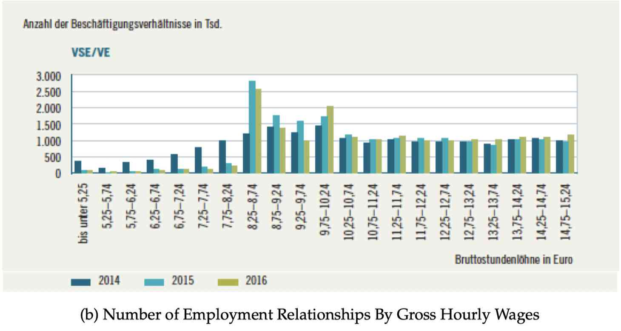

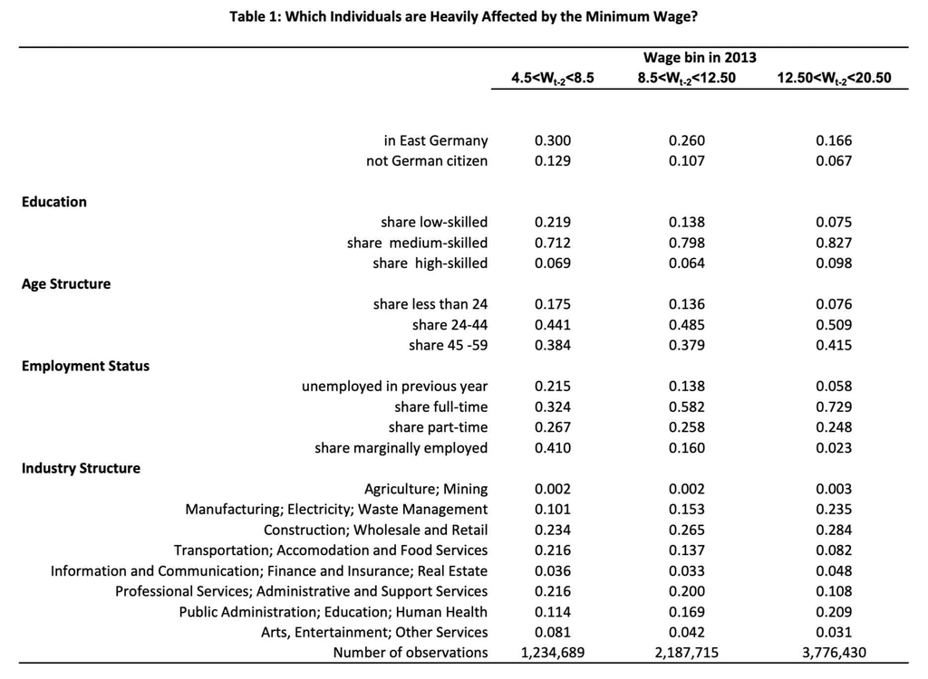

## Findings

- The minimum wage significantly increased wages of low-wage workers
- There is no indication that it lowered the employment prospects
- The minimum wage reallocated workers to higher quality establishments with higher average wage, larger size, lower churning rate, and higher productivity
- Minimum wages increased allocation efficiency of workers; though not all minimum wage workers are necessarily better off

## Data

- Individual-level German administrative records
  - Federal Employment Agency’s Statistics Department, merged with
  - Employee Histories of the Institute for Employment Research (BeH)
- Include all workers covered by the social security system
- Hourly wage before 2014; “proxied” hourly wage after 2014
- Yearly panel from 2011 to 2016
- Individual approach / regional approach

## Labor Market Effect of the Minimum Wage: Individual Approach

## Individual Approach

2-year Wage growth by wage bins

\[ y_{it}-y_{it-2} = \sum_k 1[b_{k-1}<w_{it-2}<b_k]\gamma_{kt} + \beta X_{it-2} + e_{it} \tag{1}\]

Confounding factor: **mean reversion**

\[ y_{it}-y_{it-2} = \sum_k 1[b_{k-1}<w_{it-2}<b_k]\gamma_{k2013} + \sum_k 1[b_{k-1}<w_{it-2}<b_k]\delta_{kt} + \beta X_{it-2} + e_{it} \tag{2}\]

Confounding factor: **macroeconomic time effects**

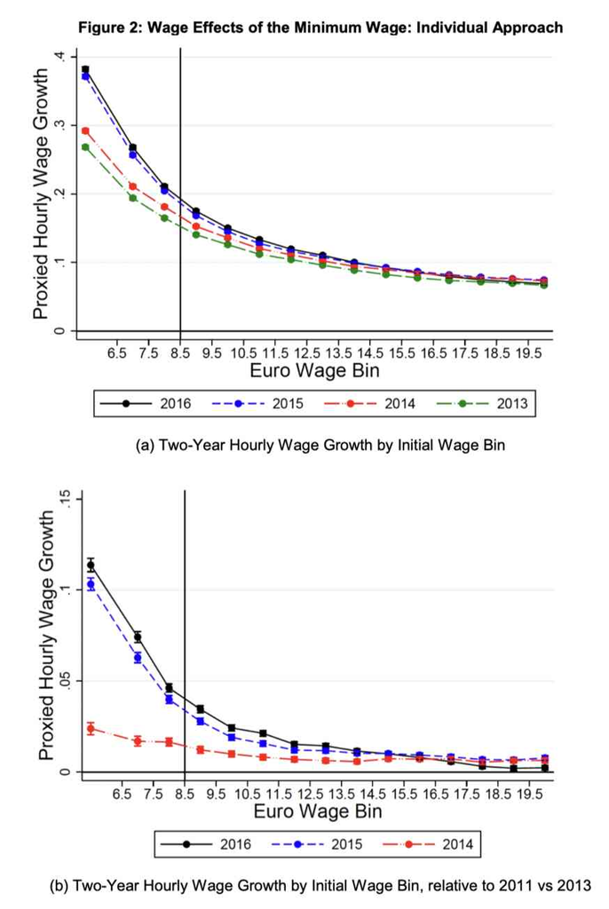

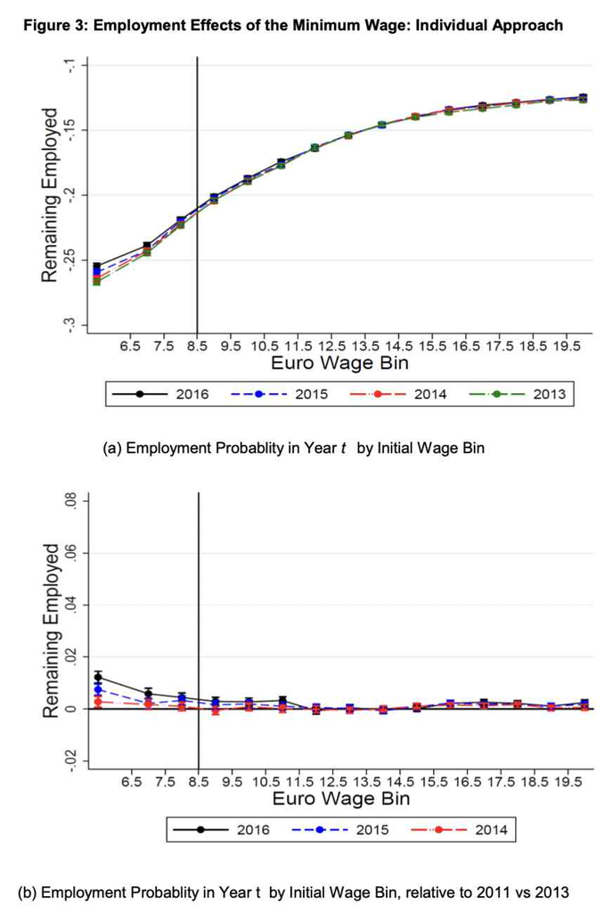

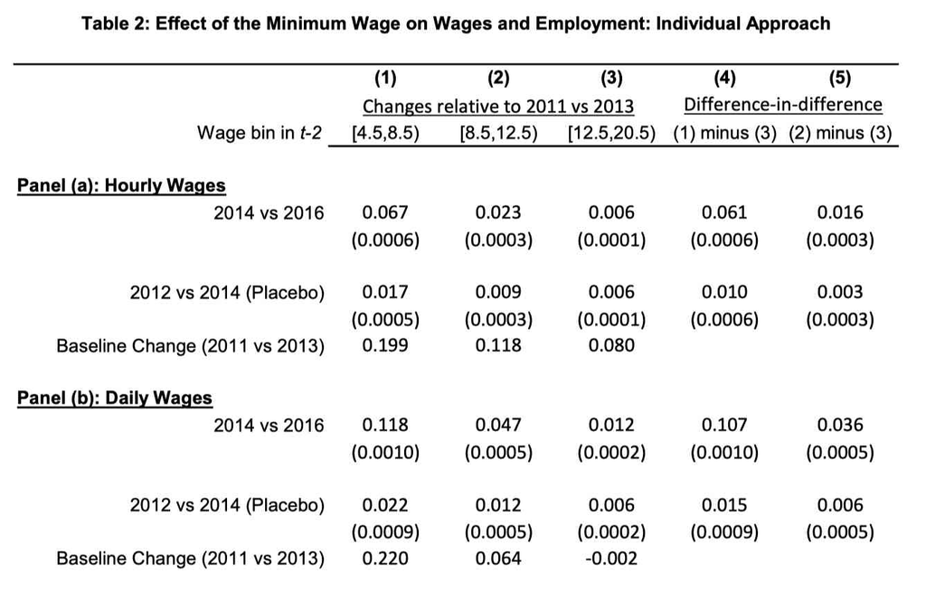

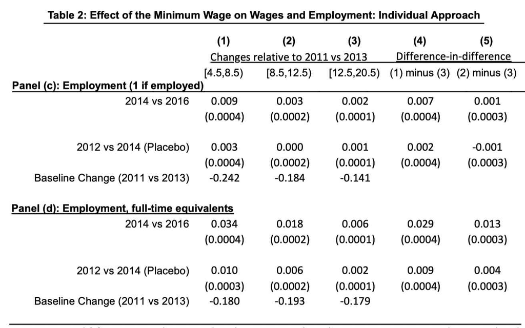

## Reallocation Effects of the Minimum Wage

Change of establishment quality

\[ q_{j(i,t)}^{l=t-2}-q_{j(i,t-2)}^{l=t-2} = \sum_k 1[b_{k-1}<w_{it-2}<b_k]\gamma_{k2013} + \sum_k 1[b_{k-1}<w_{it-2}<b_k]\delta_{kt} + \beta X_{it-2} + e_{it} \]

The “quality” of the establishments (measured only in \(t-2\))

- Average daily wage
- Share of high-skilled workers
- Share of full-time workers
- Wage premium (residuals from the wage equation, or firm’s fixed effect)
- Churning rate (share of workers leaving or joining)

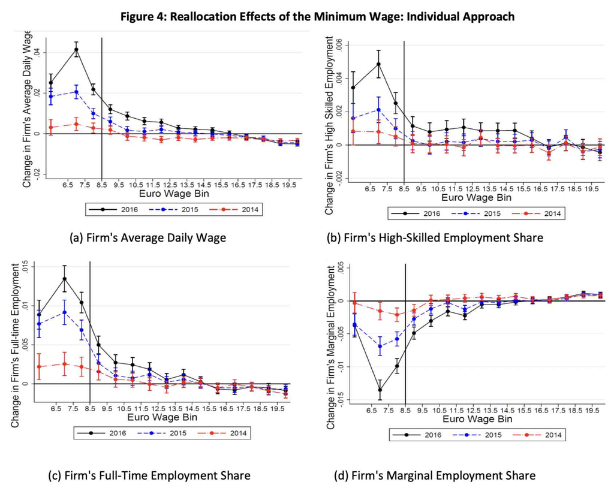

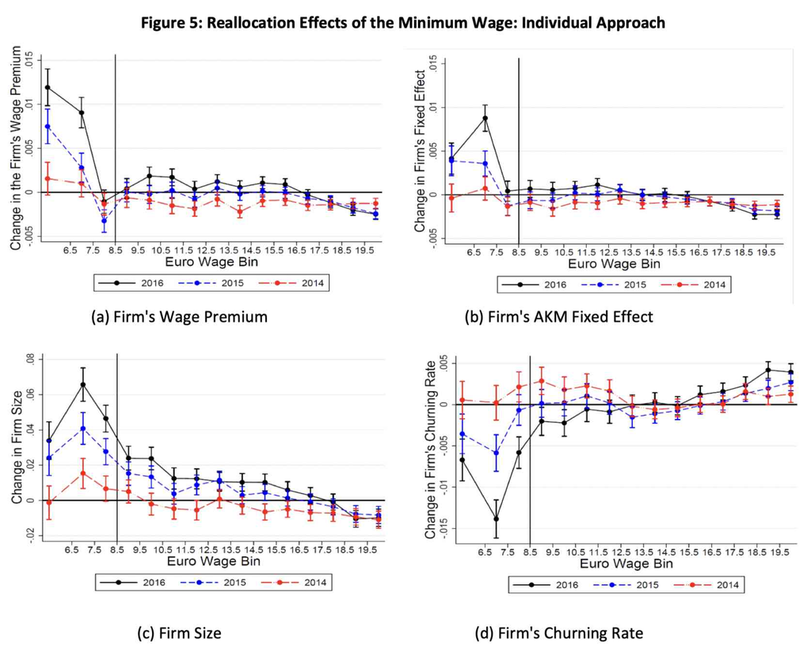

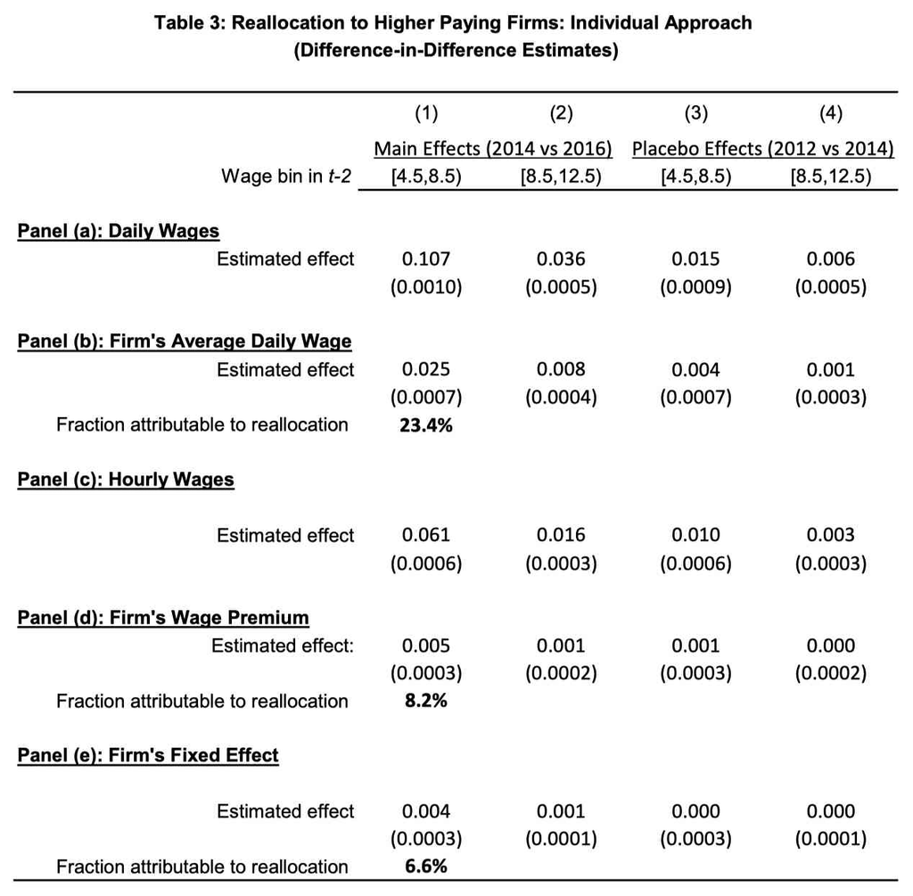

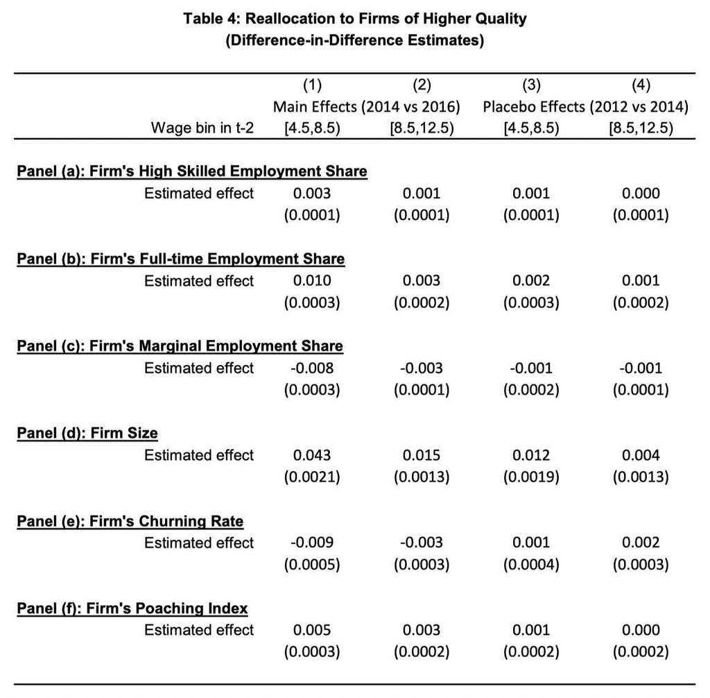

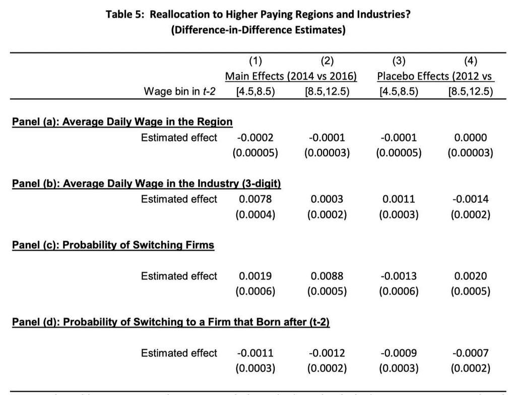

## Robustness and Heterogeneous Effects

- The results are robust with
  - Individual-level demographic controls
  - Industry and location fixed effects
  - Local unemployment rate interacted with wage bins
- The reallocation effects are similar in districts with
  - stable and declining unemployment rates
  - heavily and barely exposed to the minimum wage
- The displacement effects are stronger for workers in
  - Food, cleaning, security, and logistics service (FCSL)
  - nontradable sectors than tradable sectors

## Labor Market Effects of the Minimum Wage: Regional Approach

## Regional Approach

Measuring exposure to the minimum wage requirement

\[ \text{GAP}_r =\sum_{t=2011}^{2014}\left(\frac{\sum_{i\in r}h_{it}\max\{0,MW-w_{it}\}}{\sum_{i\in r}h_{it}w_{it}}\right)\]

Event study approach

\[Y_{rt} = \alpha_r +\xi_t+ \sum_{\tau=2011,\tau\neq 2014}^{2016} \gamma_\tau\text{GAP}_r +\epsilon_{rt} \tag{4}\]

Difference in difference approach

\[Y_{rt} = \alpha_r +\xi_t+ \delta_{post}\text{GAP}_r\times\text{Post}_t + (\beta_\tau\text{time}_t) +\epsilon_{rt} \tag{5}\]

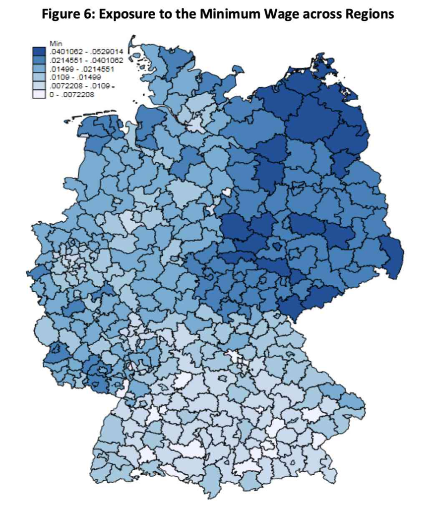

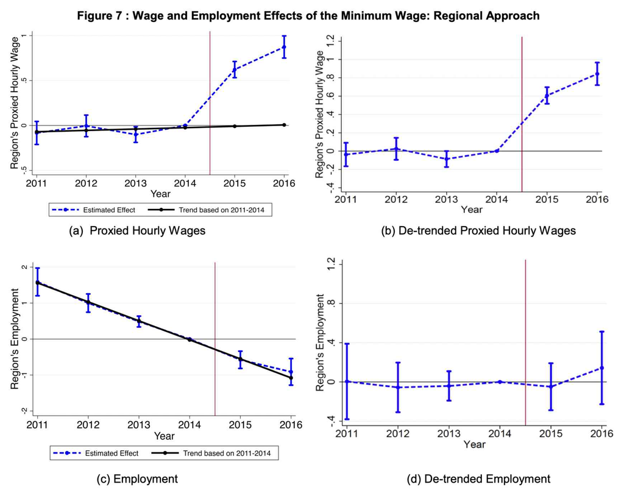

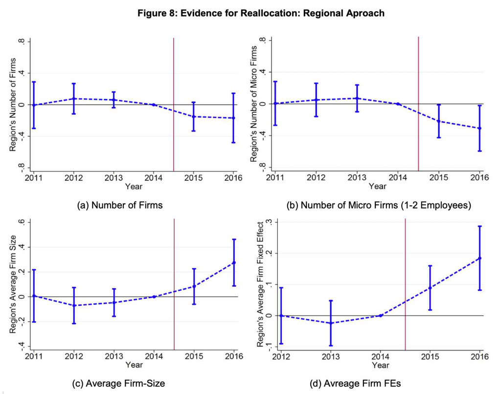

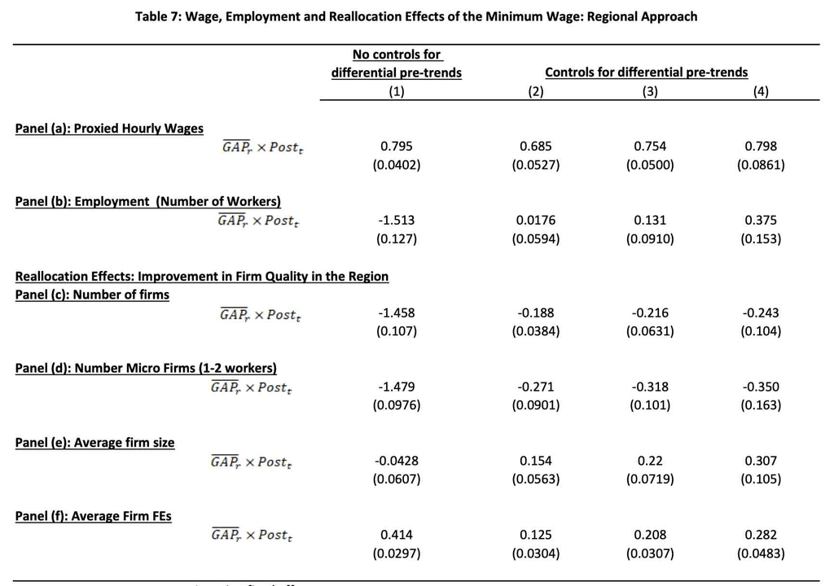

## Not everyone is better off…

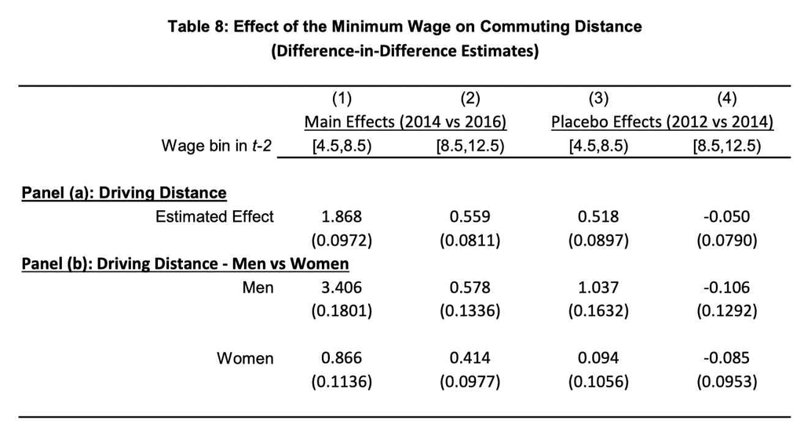

## Conclusion

- This paper investigates the labor market response to Germany’s first-time introduction of a nationwide minimum wage.
- The minimum wage policy pushed up wages without lowering employment.
- The minimum wage led to a reallocation of workers to higher quality establishments.
- The findings are consistent with a monopsonistic model of the labor market, where the reallocation came at the expense of increased commuting time.